# Evaluating Seasonal Predictions

2021-11-16

## In this talk:

- How do we evaluate forecasts in general?
- Evaluating Seasonal forecasts using the `R`-package `Seaval`
- Example: evaluation of the October 2021 precipitation prediction issued at the September GHACOF
- Evaluating past predictions helps us understand forecast deficits and strengths
- Did the seasonal forecast exhibit skill (was it better than the climatology forecast)?
- In what regions was skill high, where was it low?
- We need to use performance measures that
  - reward better forecast
  - allow comparison to climatology

## Evaluation-pipeline:

- load your prediction (in a suitable format)
- get observations, including observations of past years!
- scale observations and predictions onto the same grid
- create climatology forecast for reference
- Compare prediction and climatology forecast using objective performance metrics

## Evaluating tercile forecasts

- Seasonal precipitation predictions are often issued in terms of three probabilities: one for low, one for normal, and one for high precipitation.
- The following score is called the *multicategory Brier skill score*: \[MBSS := \frac{3}{2}(2/3 - (p_1 - e_1)^2 + (p_2 - e_2)^2 + (p_3 - e_3)^2).\] Here, \(p_1,p_2,\) and \(p_3\) are the predicted probabilities for the three categories, and \(e_i\) is 1 if the observation falls in the \(i\)th category, and 0 else.
  - \(MBSS = 0\): your forecast is as good as climatology
  - \(MBSS > 0\): it is better
  - \(MBSS = 1\): your forecast is perfect.

## The `SeaVal` package

- `R` package for validation of seasonal forecasts
- Currently developed at the Norwegian Computing Center with input from ICPAC
- Provides tools for evaluating forecasts, including data import/export and plotting
- getting started:
- Install the open-source statistical programming software `R`
- type the following:

```r
install.packages('devtools')
devtools::install_github('SeasonalForecastingEngine/SeaVal')
```

should work on every laptop/server, wherever you are…

## Example: evaluating the October 2021 precipitation forecast

get the forecast as netcdf (not shown), and import as `R` data table:

```r
setwd('/nr/project/stat/CONFER/Data/validation/example_data/202109/')
prediction = netcdf_to_dt('PredictedProbabilityRain_Oct_Sep2021.nc',
                          verbose = 0)
print(prediction[!is.na(below)][1:5,])
```

```
##     lon   lat    below   normal    above
## 1: 20.5 -11.8 40.14280 28.69145 31.16575
## 2: 20.5 -11.7 39.71079 28.69912 31.59009
## 3: 20.5 -11.6 39.23802 28.73168 32.03030
## 4: 20.5 -11.5 38.64296 28.83887 32.51817
## 5: 20.5 -11.4 38.76350 28.00487 33.23163
```

## get observations:

```r
download_chirps(temp_res = 'monthly',
                save_dir = '/nr/project/stat/CONFER/Data/CHIRPS/')
obs = process_chirps(temp_res = 'monthly',
              chirps_dir = '/nr/project/stat/CONFER/Data/CHIRPS/')
# subset October
obs = obs[month == 10]
print(obs)
```

```
##          lon   lat       prec year month
##      1: 22.0 -12.0 1.93015872 1981    10
##      2: 22.0 -11.5 2.13516024 1981    10
##      3: 22.0 -11.0 2.76928827 1981    10
##      4: 22.0 -10.5 3.92016187 1981    10
##      5: 22.0 -10.0 4.87206560 1981    10
##     ---
## 142840: 51.5  21.0 0.05456387 2021    10
## 142841: 51.5  21.5 0.04418334 2021    10
## 142842: 51.5  22.0 0.03746422 2021    10
## 142843: 51.5  22.5 0.03058102 2021    10
## 142844: 51.5  23.0 0.02482439 2021    10
```

## derive climatology:

```r
obs = add_tercile_cat(obs)
print(obs)
```

```
##          lon   lat       prec year month tercile_cat
##      1: 22.0 -12.0 1.93015872 1981    10          -1
##      2: 22.0 -11.5 2.13516024 1981    10          -1
##      3: 22.0 -11.0 2.76928827 1981    10          -1
##      4: 22.0 -10.5 3.92016187 1981    10           1
##      5: 22.0 -10.0 4.87206560 1981    10           1
##     ---
## 142840: 51.5  21.0 0.05456387 2021    10           1
## 142841: 51.5  21.5 0.04418334 2021    10           1
## 142842: 51.5  22.0 0.03746422 2021    10           1
## 142843: 51.5  22.5 0.03058102 2021    10          -1
## 142844: 51.5  23.0 0.02482439 2021    10          -1
```

## join observation and prediction:

```r
eval_dt = merge(prediction, obs[year == 2021],
                by = c('lon','lat'))
eval_dt[,year := NULL][,month := NULL]
print(eval_dt)
```

```
##        lon   lat    below   normal    above       prec tercile_cat
##    1: 22.0 -12.0       NA       NA       NA 2.44252324           0
##    2: 22.0 -11.5 43.01535 26.63268 30.35197 2.71348956          -1
##    3: 22.0 -11.0 43.83388 26.19113 29.97499 3.04330647          -1
##    4: 22.0 -10.5 42.63013 24.77941 32.59045 3.80215030           0
##    5: 22.0 -10.0 40.34092 30.19848 29.46060 3.91896243           0
##   ---
## 3480: 51.5  21.0       NA       NA       NA 0.05456387           1
## 3481: 51.5  21.5       NA       NA       NA 0.04418334           1
## 3482: 51.5  22.0       NA       NA       NA 0.03746422           1
## 3483: 51.5  22.5       NA       NA       NA 0.03058102          -1
## 3484: 51.5  23.0       NA       NA       NA 0.02482439          -1
```

## plot observations:

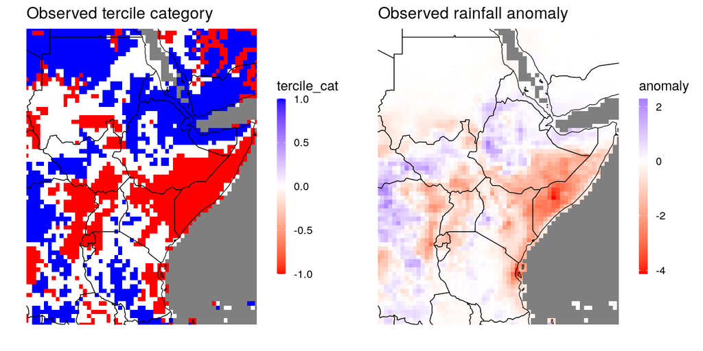

## plot predictions:

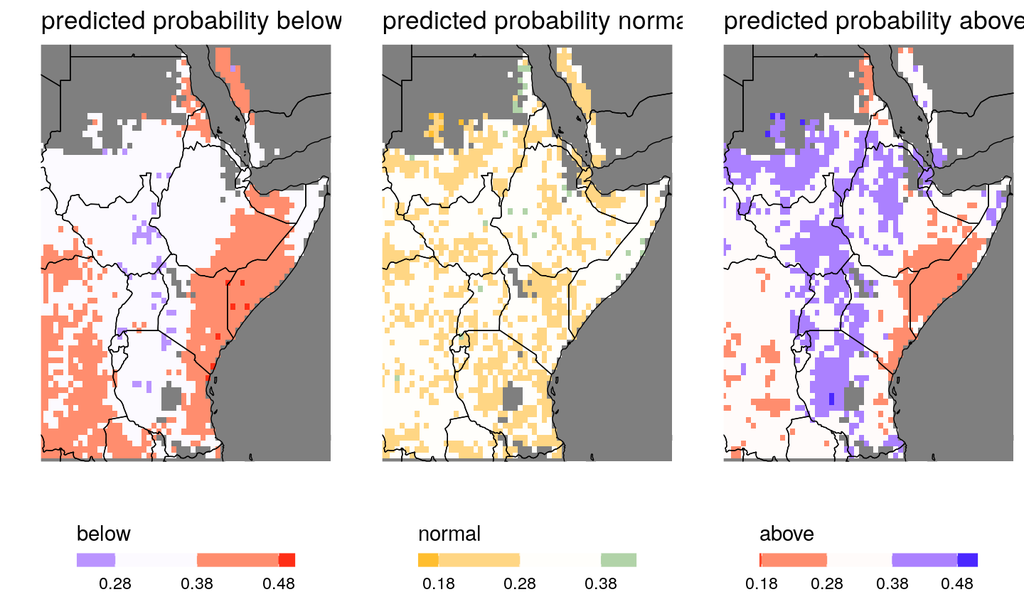

## evaluate prediction

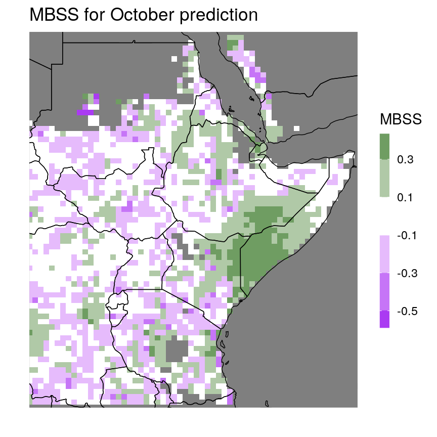

## summary

The `SeaVal` package provides functionality for:

- importing predictions as netcdf
- downloading observations (CHIRPS)
- matching data on different grids
- evaluating forecasts
- plotting results
- exporting netcdfs
- more to come…

More information is available at

[http://files.nr.no/samba/CONFER/SeaVal/]